# Notebook

Last modified

Sep, 2025

06

10:45:41 AM

Discrete Fourier Transform

ADC; DAC; sampling; quantization; quantization error;

## References

1. [DSP Guide, Steven W. Smith.](http://www.dspguide.com/ch8.htm)

## Problem Statement

To follow reference 1 and learn how to implement DFT from scratch.

## Signal

Think of signal as an array of numbers that contains information about the system it is derived from.  
For e.g., You recorded your voice using a microphone and stored it in your computer. So you have a signal $y[t]$ that captured your voice. The signal here is discrete signal which we will talk about soon.

## Types of Signal

1. **Aperiodic-Continuous**: It extends from $-\infty \rightarrow +\infty$ without any repeating pattern or periodicity. It is defined at all points.
2. **Periodic-Continuous**: It extends from from $-\infty \rightarrow +\infty$ with repeating pattern or periodicity. It is defined at all points.
3. **Aperiodic-Discrete**: It extends from from $-\infty \rightarrow +\infty$ without repeating pattern or periodicity. It is defined at discrete points.
4. **Periodic-Discrete**: It extends from from $-\infty \rightarrow +\infty$ with repeating pattern or periodicity. It is defined at discrete points.

All these signals extend from $-\infty \rightarrow +\infty$ which is not something that we can store in computers. Indeed all the transforms that we typically deal with requires the signal to extend to $\infty$, so is the case with Fourier Transform. The workaround to this problem is to assume that the finite signal is extended on both sides (with either the values being 0 or the values being repeated).

## Transform

Think of transform as a mapping system that takes a signal and changes it into another signal. The values, type do not need to be preserved after transformation. For e.g., If I apply a tranformation on a 200-points discrete signal, it can output a signal which is continuous or 400-points dicrete signal or just 1-point discrete signal. All of these are valid transformations.

**Fourier Transform** is one such transform and is a special case of something called **Integral Transform** which we can talk about some other time.

## Versions of Fourier Transform

Based on the type of signal, we have different versions of Fourier Transform. I have mentioned in the figure below.

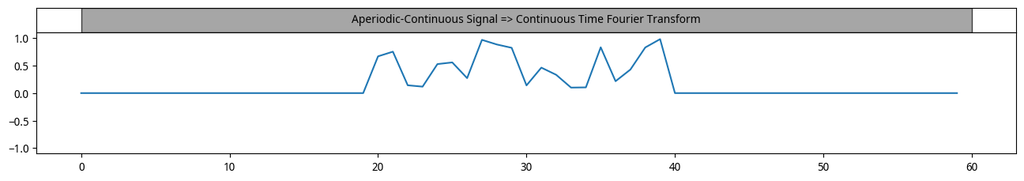

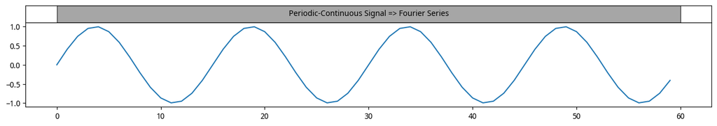

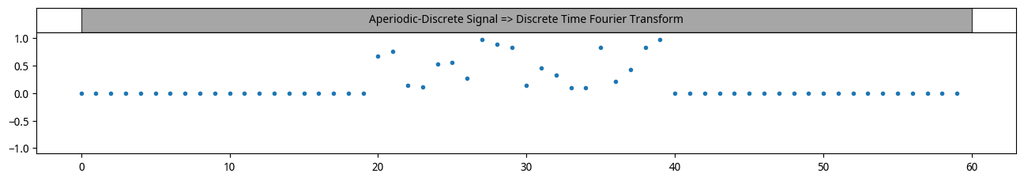

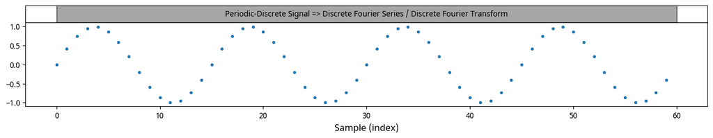

The first three versions are more like *pen-and-paper transforms* where you would have to solve equations analytically to get deeper insight into the system behaviour. The fourth version is what is used in almost all digital domain where we assume that the signal is periodic and discrete.

## Discrete Fourier Transform

Just so you know about the nomenclature, we call the process of calculating DFT with many names: decomposition, analysis, DFT, forward-DFT Similarly the process of calculating the signal back is known by synthesis or inverse-DFT.

When we apply DFT to a time-domain signal $y[t]$, the independent variable meaning changes, we move from $y[t] \rightarrow Y[f]$ where $t$ and $f$ correspond to time (sec) and frequency (hz) respectively.

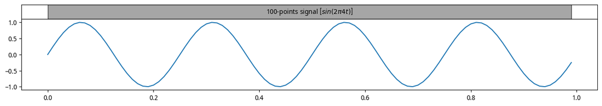

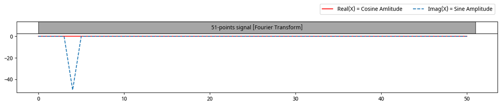

## Pure Sines/Cosines

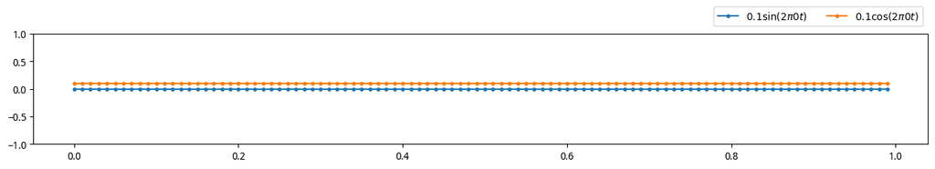

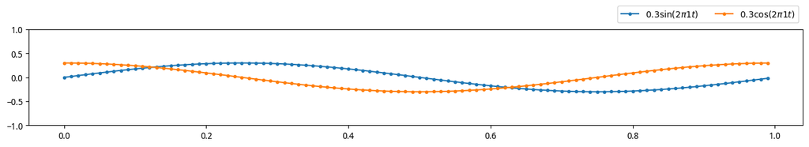

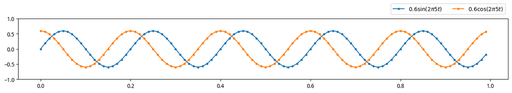

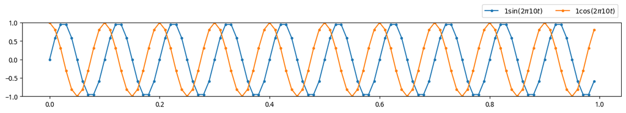

```python
import numpy as np
import modusa as ms

sines = []
cosines = []

fs = [0, 1, 5, 10]
As = [0.1, 0.3, 0.6, 1]

dt = 0.01 # sec
t = np.arange(0, 1, dt)

for f, A, phi in zip(fs, As, phis):
    sines.append(A * np.sin(2*np.pi*f*t))
    cosines.append(A * np.cos(2*np.pi*f*t))

    # Visualisation
    fig = ms.fig1d(0, ylim=(-1, 1))
    fig.add_signal(sines[-1], t, m="o", label=f"${A}\\sin(2\\pi {f} t)$")
    fig.add_signal(cosines[-1], t, m="o", label=f"${A}\\cos(2\\pi {f} t)$")
    fig.add_legend(1.1)
```

## Discrete Fourier Transform

## Short-time Fourier Transform